# BIOC557: CCLE: protein, RNA and metabolites

A complete default analysis in R

# 1 Start here

This report runs one fixed set of starting settings. Every data file is included in the teaching package. There is no parameter menu to complete.

For your first run, open **BIOC557.Rproj**, open **START_HERE.R**, and click **Source** in RStudio. It installs the missing packages and builds this report. After that, open **BIOC557_Default_Lab.Rmd** and click **Knit**.

The code below is written in small steps. Read a section, look at its plot, and use the short question to think about what the measurements show.

# 2 Read the demo data

Protein and RNA measurements use the same sample identifiers. Metabolite measurements, when present, follow those sample identifiers too.

```r
course <- read_course_study()
study <- course$study
settings <- course$settings

knitr::kable(course_settings_table(course))
```

| Setting | Value |
| --- | --- |
| Dataset | CCLE: protein, RNA and metabolites |
| Matched samples | 61 |
| Analysis | Multi-Omics Factor Analysis (MOFA) |
| MOFA factors | 6 |
| Model features per view | 100 |
| Feature scaling | none |
| Protein/RNA alignment | Same gene IDs; same column order |
| Center features | Yes |
| Scale whole views | Yes |
| Seed | 557 |
| Maximum iterations | 300 |

The sample table tells us which measurements belong together.

```r
knitr::kable(head(study$metadata[, c("sample_id", "group")]))
```

| sample_id | group |
| --- | --- |
| ACH-000248 | Breast |
| ACH-000536 | Breast |
| ACH-000288 | Breast |
| ACH-000856 | Breast |
| ACH-000857 | Breast |
| ACH-000783 | Breast |

# 3 Prepare the molecular views

The supplied measurements are already on their published logarithmic scales. We keep features that pass the missingness filter, select the default variable features, and apply the selected scaling. Protein and RNA use the same genes in the same column order.

```r
lab <- run_lab(study,
               max_missing = settings$max_missing,
               model_features = settings$model_features,
               feature_scaling = settings$feature_scaling,
               feature_alignment = "matched_genes",
               mofa_center = settings$mofa_center)

knitr::kable(course_qc_table(lab))
```

| View | Samples | Input_features | Retained_features | Model_features | Missing_percent |
| --- | --- | --- | --- | --- | --- |
| Proteomics | 61 | 1200 | 919 | 100 | 15.2 |
| RNA | 61 | 1200 | 1200 | 100 | 0.0 |
| Metabolomics | 61 | 225 | 225 | 100 | 0.0 |

## 3.1 Check missing measurements

Each bar shows the fraction of missing input measurements in one sample.

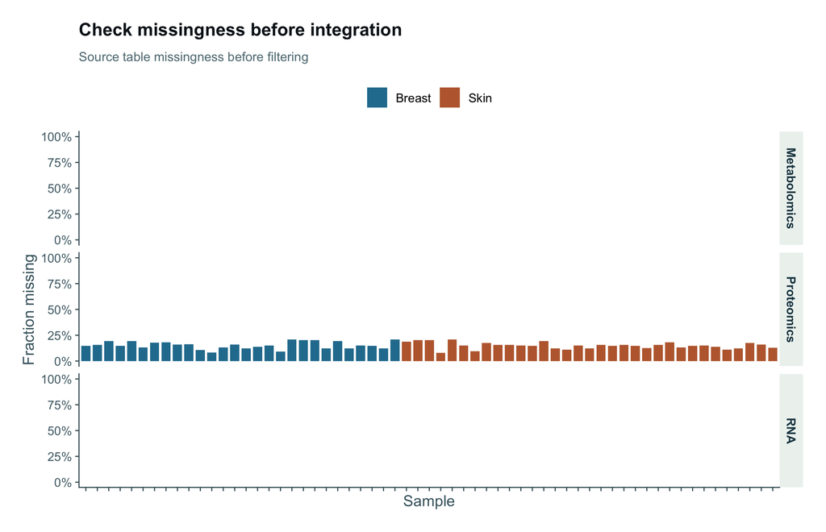

```r
quality_plot <- plot_quality(lab)
course_save_figure(quality_plot, "01_missingness")
```

**Think about it:** Which molecular view has the most missing measurements?

# 4 Look at each view with PCA

Principal Component Analysis (PCA) reduces many features to a few axes. Each point is one matched sample. Colors show the study groups after the axes have been calculated.

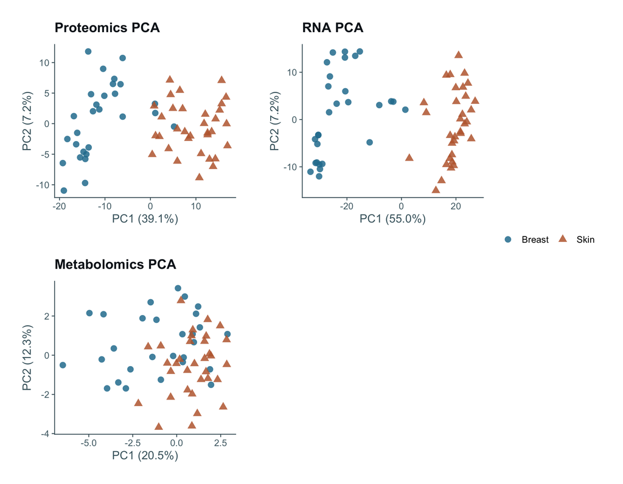

```r
pca_plot <- course_pca_panel(lab)
course_save_figure(pca_plot, "02_single_view_pca", height=7)
```

## 4.1 Combine the views with joint PCA

The joint matrix puts the molecular views side by side and balances their feature counts. The axes below describe the combined measurements.

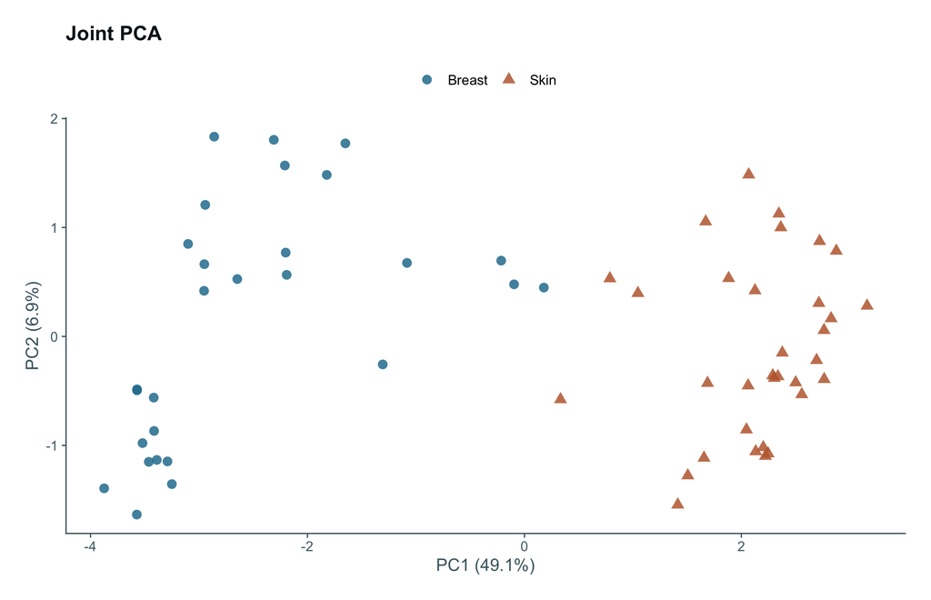

```r
joint_plot <- course_joint_pca(lab)
course_save_figure(joint_plot, "03_joint_pca")
```

**Think about it:** Do the separate views tell a similar story about the samples?

# 5 Compare RNA and protein for one gene

Each point pairs the RNA and protein measurement of the same gene in the same sample. The default gene is selected from genes present in both views.

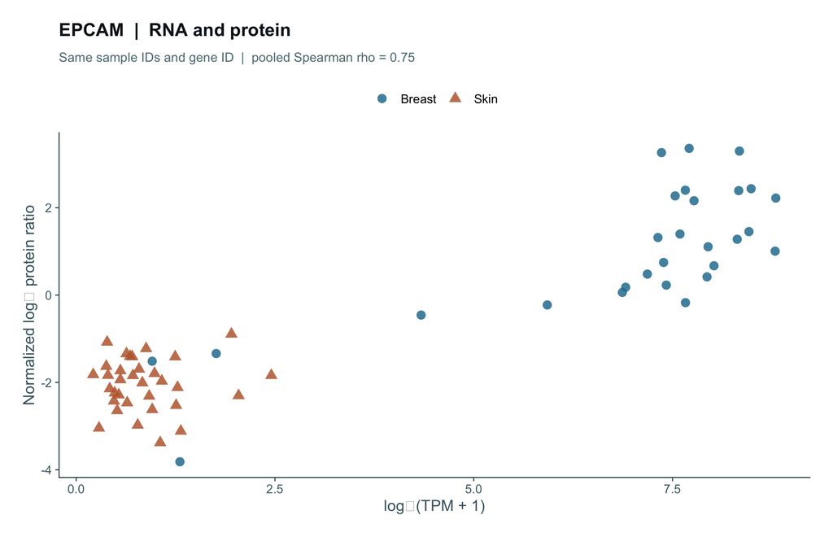

```r
gene_plot <- plot_gene_pair(lab)
course_save_figure(gene_plot, "04_rna_protein_gene")
```

**Think about it:** Do high RNA measurements always go with high protein measurements?

# 6 See the aligned feature matrix

Rows are features and columns are samples. Values are scaled within each feature for this display. Gray cells are missing observations.

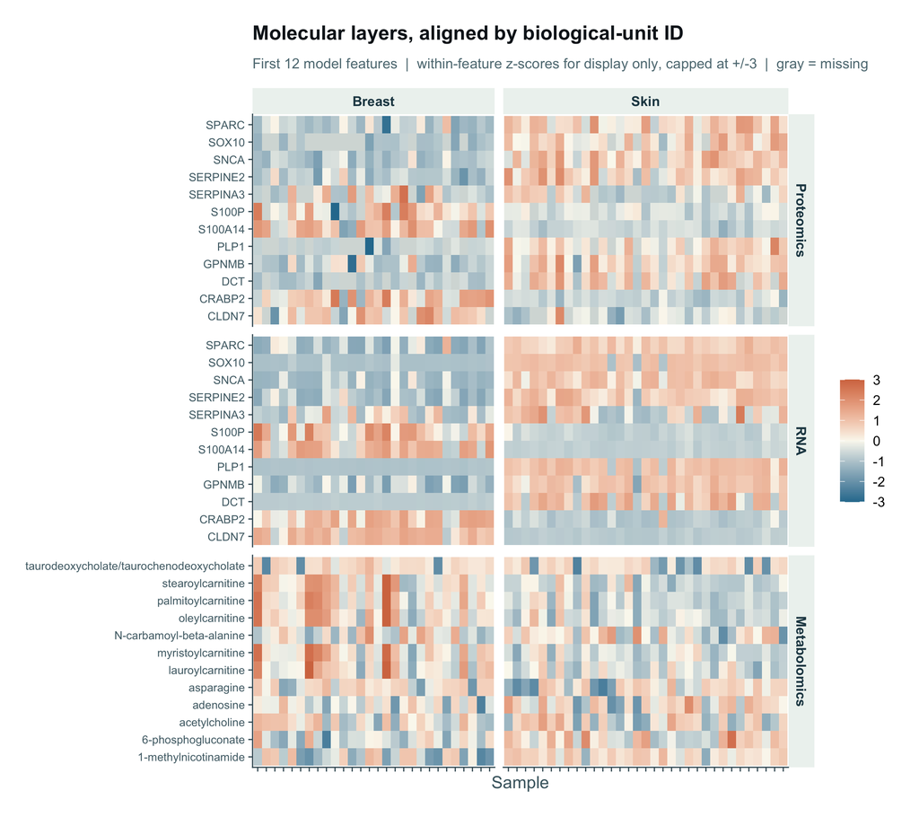

```r
feature_plot <- plot_feature_heatmap(lab)
course_save_figure(feature_plot, "05_feature_heatmap", height=8)
```

# 7 Fit the default MOFA model

Multi-Omics Factor Analysis (MOFA) describes shared and view-specific patterns with latent factors. This is one model fit with a fixed random seed of 557. MOFA2 prepares its calculation environment automatically on the first run.

```r
mofa <- fit_lab_mofa(lab,
                     factors = settings$factors,
                     iterations = settings$iterations,
                     seed = 557,
                     scale_views = settings$mofa_scale_views,
                     runtime = "managed",
                     outfile = "outputs/default_MOFA.hdf5")
```

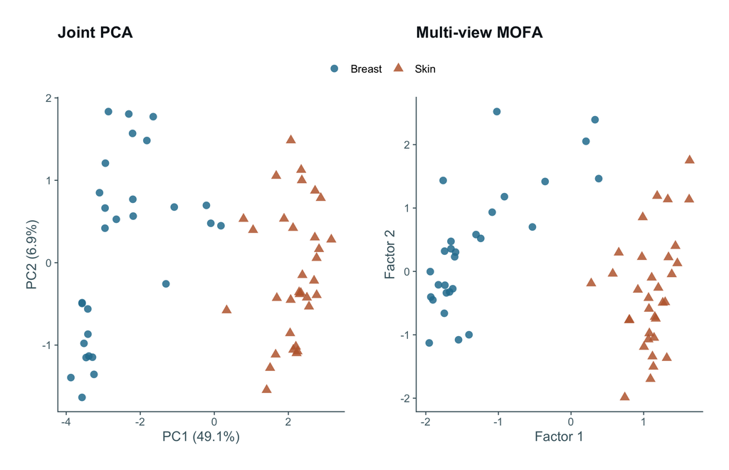

```r
integration_plot <- plot_integration(lab, mofa)
course_save_figure(integration_plot, "06_pca_and_mofa", width=11)
```

## 7.1 Which view contributes to each factor?

The percentages show reconstructed variation within each molecular view. Read each percentage against its own view. R-squared (R2) is the fraction of input variation reconstructed by the model.

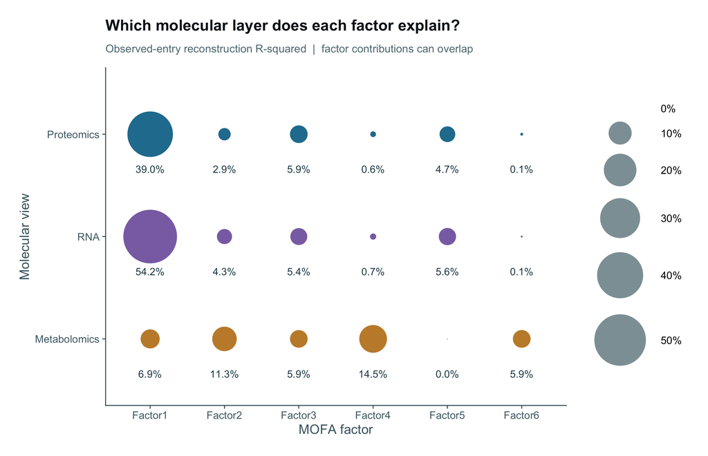

```r
contribution_plot <- plot_factor_contributions(mofa)
course_save_figure(contribution_plot, "07_factor_contributions")
```

## 7.2 How do factor scores vary between samples?

A sample can have a high score for one factor and a low score for another.

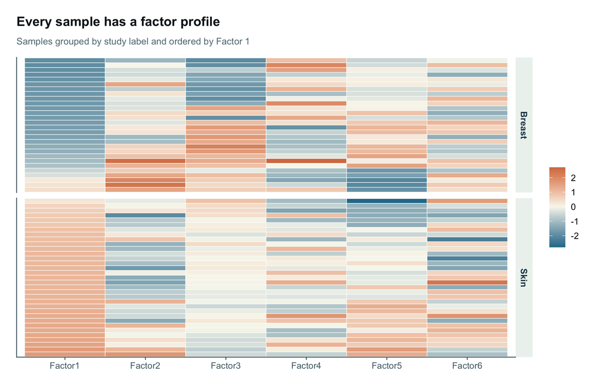

```r
score_plot <- plot_sample_factors(lab, mofa)
course_save_figure(score_plot, "08_sample_factor_scores")
```

# 8 Follow one factor

```r
focus_factor <- if(!is.null(course$config$focus_factor)) course$config$focus_factor else
  which.max(mofa$variance_explained["RNA", ])
focus_factor
```

```
## Factor1
##       1
```

## 8.1 Look at its strongest features

Positive and negative weights describe opposite ends of a factor.

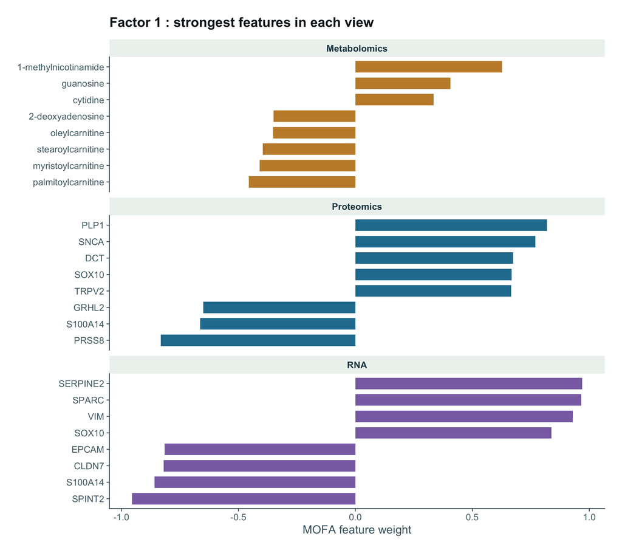

```r
weight_plot <- course_weight_plot(lab, mofa, factor=focus_factor)
course_save_figure(weight_plot, "09_factor_features", height=8)
```

## 8.2 Draw a factor network

The center is the selected factor. The surrounding nodes are features from each molecular view. Lines connect the factor to its weighted features.

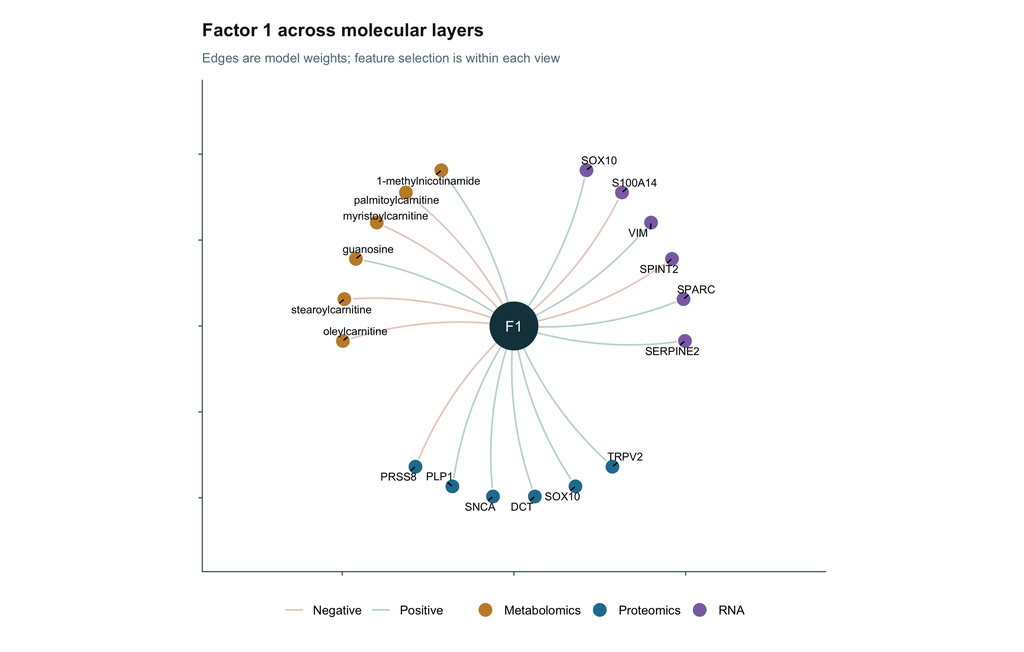

```r
network <- factor_network(lab, mofa, factor=focus_factor, top_per_view=6)
network_plot <- plot_factor_network(network)
course_save_figure(network_plot, "10_factor_network", width=11, height=7)
```

## 8.3 Connect RNA features to biological processes

Gene Ontology (GO) groups genes by their annotated functions. We test the top 20 positive-weight RNA features against the annotated model-feature background. The Benjamini-Hochberg (BH) procedure adjusts p values across all terms tested in this query. The q value is the BH-adjusted p value.

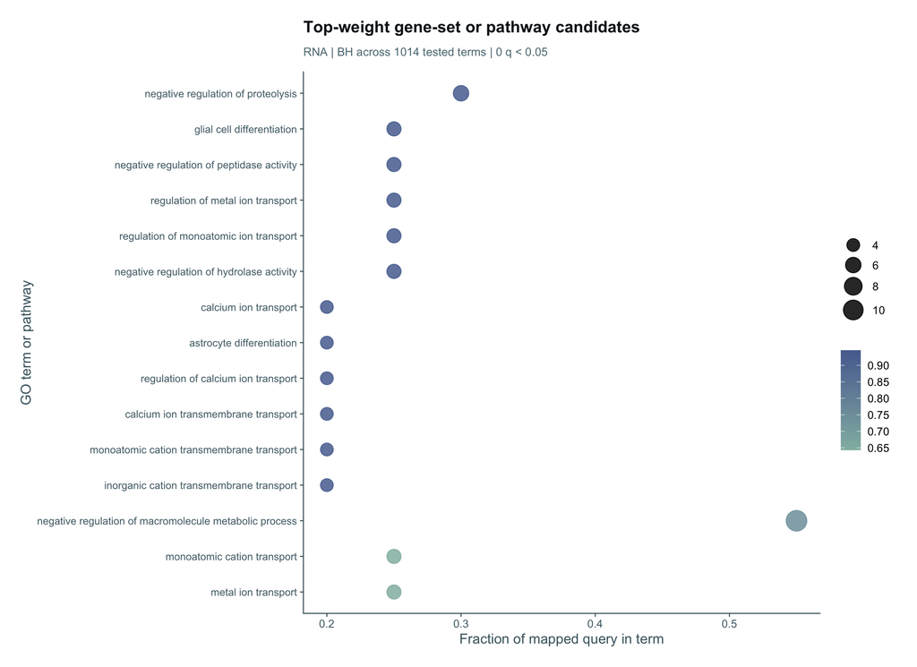

```r
annotations <- jsonlite::fromJSON(course$config$annotation_file,
                                  simplifyVector=FALSE)
go_result <- factor_enrichment(lab, mofa, annotations,
                                factor=focus_factor, view="RNA",
                                catalog="GO_BP", top_n=20,
                                direction="positive")
go_plot <- plot_pathway_results(go_result)
course_save_figure(go_plot, "11_go_processes", width=11, height=8)
```

```r
write.csv(go_result$rows, "outputs/GO_results.csv", row.names=FALSE)
```

**Think about it:** Which annotated functions appear among the selected genes? Read the q values alongside the overlapping genes.

# 9 Functional summary across all factors

The contribution percentages describe how much each molecular layer contributes. The summary q values adjust enrichment tests across all factors, views, catalogs and weight directions in this report.

```r
categories <- jsonlite::fromJSON("data/functional_categories.json", simplifyVector=FALSE)
functional <- web_functional_summary(lab, mofa, annotations, top_n=20,
                                     categories=categories)
knitr::kable(functional$factors, digits=4)
```

| factor | category | leading_term | report_q | significant_tests | views_above_1pct |
| --- | --- | --- | --- | --- | --- |
| 1 | Growth and development | system development | 0.4362 | 0 | 3 |
| 2 | Functional annotation profile | neurogenesis | 0.5672 | 0 | 3 |
| 3 | Functional annotation profile | response to toxic substance | 0.5672 | 0 | 3 |
| 4 | Functional annotation profile | Bile secretion | 1.0000 | 0 | 1 |
| 5 | Functional annotation profile | Metabolism | 0.7924 | 0 | 2 |
| 6 | Functional annotation profile | Arginine and proline metabolism | 1.0000 | 0 | 1 |

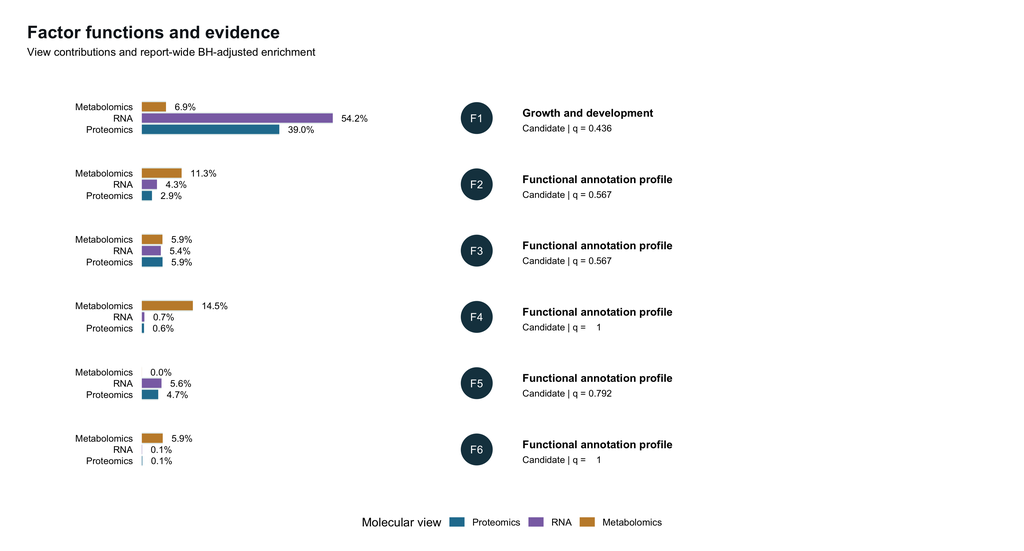

```r
summary_plot <- web_summary_plot(functional)
course_save_figure(summary_plot, "12_functional_summary", width=13, height=7)
```

```r
write.csv(functional$tests,"outputs/Summary_all_term_tests.csv",row.names=FALSE)
write.csv(functional$themes,"outputs/Summary_functional_themes.csv",row.names=FALSE)
```

# 10 Check metabolite pathway coverage

The Kyoto Encyclopedia of Genes and Genomes (KEGG) links identified compounds to pathways. This plot counts measured compounds with curated pathway mappings. It describes coverage of the measurements.

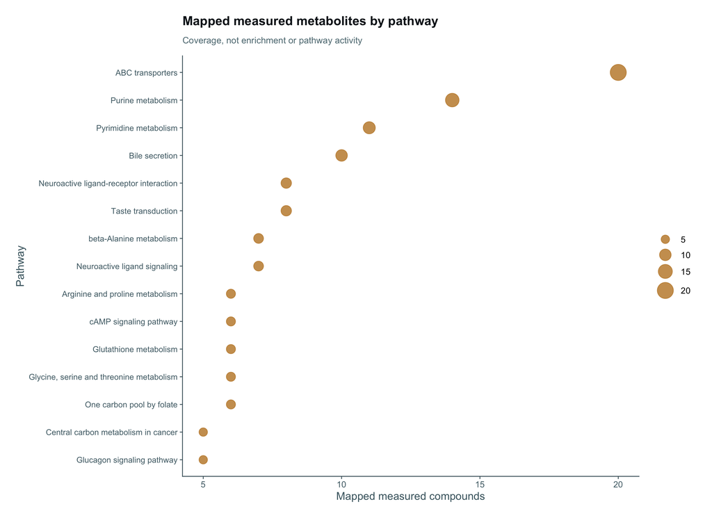

```r
coverage <- factor_enrichment(lab, mofa, annotations,
                              view="Metabolomics",
                              catalog="Metabolite_pathways",
                              mode="coverage")
coverage_plot <- plot_pathway_results(coverage)
course_save_figure(coverage_plot, "12_metabolite_coverage", width=11, height=8)
```

```r
write.csv(coverage$rows, "outputs/metabolite_coverage.csv", row.names=FALSE)
```

# 11 Save the completed analysis

The report saves the selected model matrices, gene alignment, sample metadata, result tables, settings and R session information. Each plotted figure also has PNG, PDF and SVG copies in **outputs/figures/**. PNG is a raster image, PDF is Portable Document Format, and SVG is Scalable Vector Graphics.

```r
course_save_results(course, lab, mofa)
knitr::kable(data.frame(File=list.files("outputs/figures", pattern="\\.png$")))
```

| File |
| --- |
| 01_missingness.png |
| 02_single_view_pca.png |
| 03_joint_pca.png |
| 04_rna_protein_gene.png |
| 05_feature_heatmap.png |
| 06_pca_and_mofa.png |
| 07_factor_contributions.png |
| 08_sample_factor_scores.png |
| 09_factor_features.png |
| 10_factor_network.png |
| 11_go_processes.png |
| 12_functional_summary.png |
| 12_metabolite_coverage.png |

The HTML report can be opened in a browser after the analysis finishes. The **outputs/default_analysis.rds** file stores the analysis objects in R’s serialized data format. The **outputs/run_manifest.json** file records the settings, sample and gene identifiers, and software versions in JavaScript Object Notation (JSON). CSV means comma-separated values; it is the format used for the result tables.

# 12 Data sources

- [Quantitative Proteomics of the Cancer Cell Line Encyclopedia](https://pmc.ncbi.nlm.nih.gov/articles/PMC7339254/). *Cell*, 2020.
- [Next-generation characterization of the Cancer Cell Line Encyclopedia](https://doi.org/10.1038/s41586-019-1186-3). *Nature*, 2019.
- [The landscape of cancer cell line metabolism](https://doi.org/10.1038/s41591-019-0404-8). *Nature Medicine*, 2019.

Method: Argelaguet et al. [MOFA+: a statistical framework for comprehensive integration of multi-modal single-cell data](https://doi.org/10.1186/s13059-020-02015-1). *Genome Biology*, 2020.

**One-minute recap:** We matched the samples, checked the measurements, compared the molecular views, and summarized their main patterns. Pick one plot and explain its axes and one result to a classmate.